# Ex 14 Random Variables

## 14.1 Exercises: Random Variables

### 14.1.1 Qn

> 1. In American Roulette you can also bet on green. There are 18 reds, 18 blacks and 2 greens (0 and 00). What are the chances the green comes out?

Variant in Book: Gambler can bet a dollar ($1) on red or black to win a dollar, the payout is a dollar and the casino loses one dollar. If the gambler bets on red and the ball lands in a green or black pocket, the gambler loses, but the casino (“bank”) wins. The chances are 18/38(=9/19): lose for the casino, win for the gambler and 20/38(=10/19): win for casino, lose for gambler. If the gambler is allowed to bet on green then he loses if the ball lands on red or black.

### 14.1.2 Qn

> 2. The payout for winning on green is $17 dollars. This means that if you bet a dollar and it lands on green, you get $17. Create a sampling model using sample to simulate the random variable $X$ for your winnings. Hint: see the example below for how it should look like when betting on red.

> ```r
> x <- sample(c(1,-1), 1, prob = c(9/19, 10/19))
> ```

In this variant the gambler is betting a dollar but can win $17 or lose a dollar. The casino, on the other hand, can win a dollar or lose $17. This variant is more attractive for the gambler but rises the risk of losing money for the casino.

```r
X <- sample(c(1,-17), 1, prob=c(18/19, 1/19))
X
```

```
## [1] 1
```

### 14.1.3 Qn

> 3. Compute the expected value of $X$.

Here $a=-17$ and $b=1$ with $p=1/19$ and $(1-p)=18/19$.
$$\mbox{E}[X] = ap + b(1-p)$$
Here the expected value of a single game would be 5 cent.
$$-17*1/19+1*18/19=1/19\approx0.05263$$

```r
-17*1/19 + 1 * 18/19
```

```
## [1] 0.05263158
```

This is the same expected value as betting on red. Therefore if 1000 people would bet on green the expected win for the casino stays at $50.

### 14.1.4 Qn

> 4. Compute the standard error of $X$.

$$\mbox{SE}[X]=\mid b - a \mid \sqrt{(1-p)p}$$
In this case the standard error of $X$ is
$$\mid 1 - (-17) \mid \sqrt{18/19 \times 1/19}=18*\sqrt{\frac{18}{361}}=18*\frac{\sqrt{18}}{19}\approx4$$

In numbers this results to $\approx$$4.

```r
18 * sqrt(18)/19
```

```
## [1] 4.019344
```

This is the standard error for any single game.

### 14.1.5 Qn

> 5. Now create a random variable $S$ that is the sum of your winnings after betting on green 1000 times. Hint: change the argument `size` and `replace` in your answer to question 2. Start your code by setting the seed to 1 with `set.seed(1)`.

```r
set.seed(1)
n<-10^3
X <- sample(c(-17,1), size = n, replace = TRUE, prob=c(1/19, 18/19))
S<-sum(X)
S
```

```
## [1] 10
```

### 14.1.6 Qn

> 6. What is the expected value of $S$?

```r
n<-10^3
n * (-17*1/19 + 1 * 18/19)
```

```
## [1] 52.63158
```

Here, the expectation value of thousand games yields to about 53 dollars. Therefore, the casino would win 53 dollars on average, if someone played 1000 games.

### 14.1.7 Qn

> 7. What is the standard error of $S$?

```r
n<-10^3
sqrt(n) * 18 * sqrt(18)/19
```

```
## [1] 127.1028
```

The value of the standard error tells us how large the variation might be around the expected value. Therefore, in the worst case we might add another 127 dollars to our wins or loose 127 from our average winnings.

### 14.1.8 Qn

> 8. What is the probability that you end up winning money? Hint: use the CLT.

This time the probability of loosing money is very high with about 34%, comparing to the probability of betting on red of about 5%. Therefor as a casino the probability of winning money is just 66% instead of 95% when betting on red or black.

```r
n<-1000
mu <- n * (1)/19
se <-  sqrt(n) * 18 * sqrt(18)/19
```

[output not shown]

```r
pnorm(0, mu, se)
```

```
## [1] 0.3394053
```

### 14.1.9 Qn

> 9. Create a Monte Carlo simulation that generates 1,000 outcomes of $S$. Compute the average and standard deviation of the resulting list to confirm the results of 6 and 7. Start your code by setting the seed to 1 with `set.seed(1)`.

```r
set.seed(1)
n<-10^3
B <- 10^4
roulette_winnings <- function(n){
  X <- sample(c(-17,1), n, replace = TRUE, prob=c(1/19, 18/19))
  sum(X)
}
XS <- replicate(B, roulette_winnings(n))
S<-sum(XS)/length(XS)
SE<-sqrt(sum((XS - S)^2) / length(XS))
S
```

```
## [1] 52.3324
```

```r
SE
```

```
## [1] 126.9699
```

```r
set.seed(1)
n <- 1000
B <- 10000
roulette_winnings <- function(n){
  X <- sample(c(-17,1), n, replace = TRUE, prob=c(1/19, 18/19))
  sum(X)
}
S <- replicate(B, roulette_winnings(n))

mean(S)
```

```
## [1] 52.3324
```

```
#> [1] 53.5
```

```r
sd(S)
```

```
## [1] 126.9762
```

```
#> [1] 126.2
```

```r
mean(S < 0)
```

```
## [1] 0.3391
```

```
#> [1] 0.337
```

```r
n * (2)/38
```

```
## [1] 52.63158
```

```
#> [1] 52.6
```

```r
sqrt(n) * 18 * sqrt(18)/19
```

```
## [1] 127.1028
```

```
#> [1] 127.1
```

```r
# CLT
mu <- n * (2)/38
se <-  sqrt(n) * 18 * sqrt(18)/19
pnorm(0, mu, se)
```

```
## [1] 0.3394053
```

```
#> [1] 0.339
```

### 14.1.10 Qn

> 10. Now check your answer to 8 using the Monte Carlo result.

```r
set.seed(1)
n <- 1000
B <- 10000
roulette_winnings <- function(n){
  X <- sample(c(-17,1), n, replace = TRUE, prob=c(1/19, 18/19))
  sum(X)
}
S <- replicate(B, roulette_winnings(n))

mean(S < 0)
```

```
## [1] 0.3391
```

```
#> [1] 0.337
```

### 14.1.11 Qn

> 11. The Monte Carlo result and the CLT approximation are close, but not that close. What could account for this?
> 1. 1,000 simulations is not enough. If we do more, they match.
> 2. The CLT does not work as well when the probability of success is small. In this case, it was 1/19. If we make the number of roulette plays bigger, they will match better.
> 3. The difference is within rounding error.
> 4. The CLT only works for averages.

Answer B. 14.7.1 “Note, for example, that when the probability of success is very small, we need much larger sample sizes.”

### 14.1.12 Qn

> 12. Now create a random variable $Y$ that is your average winnings per bet after playing off your winnings after betting on green 1,000 times.

```r
set.seed(1)
n<-2500
X <- sample(c(-17,1), n, replace = TRUE, prob=c(1/19, 18/19))
Y<-mean(X)
Y
```

```
## [1] 0.0136
```

### 14.1.13 Qn

> 13. What is the expected value of $Y$?

```r
set.seed(1)
n<-2500
n * (2)/38
```

```
## [1] 131.5789
```

```
#> [1] 52.6
```

### 14.1.14 Qn

> 14. What is the standard error of $Y$?

```r
set.seed(1)
n<-2500
sqrt(n) * 18 * sqrt(18)/19
```

```
## [1] 200.9672
```

```
#> [1] 127.1
```

### 14.1.15 Qn

> 15. What is the probability that you end up with winnings per game that are positive? Hint: use the CLT.

As the number of games increases it is more likely that the casino will win money by 75%, in line with the saying that the bank always wins.

```r
n<-2500
mu <- n * 1/19
se <-  sqrt(n) * 18 * sqrt(18)/19
pnorm(0, mu, se)
```

```
## [1] 0.2563213
```

### 14.1.16 Qn

> 16. Create a Monte Carlo simulation that generates 2,500 outcomes of $Y$. Compute the average and standard deviation of the resulting list to confirm the results of 6 and 7. Start your code by setting the seed to 1 with `set.seed(1)`.

```r
set.seed(1)
n <- 2500
B <- 10000
roulette_winnings <- function(n){
  Y <- sample(c(-17,1), n, replace = TRUE, prob=c(1/19, 18/19))
  sum(Y)
}
Y <- replicate(B, roulette_winnings(n))
S<-sum(Y)/length(Y)
SE<-sqrt(sum((Y - S)^2) / length(Y))
S
```

```
## [1] 131.7886
```

```r
SE
```

```
## [1] 199.4698
```

### 14.1.17 Qn

> 17. Now check your answer to 8 using the Monte Carlo result.

```r
set.seed(1)
n <- 2500
B <- 10000
roulette_winnings <- function(n){
  Y <- sample(c(-17,1), n, replace = TRUE, prob=c(1/19, 18/19))
  sum(Y)
}
S <- replicate(B, roulette_winnings(n))

mean(S < 0)
```

```
## [1] 0.262
```

```
#> [1] 0.0458
```

### 14.1.18 Qn

> 18. The Monte Carlo result and the CLT approximation are now much closer. What could account for this?
> 1. We are now computing averages instead of sums.
> 2. 2,500 Monte Carlo simulations is not better than 1,000.
> 3. The CLT works better when the sample size is larger. We increased from 1,000 to 2,500.
> 4. It is not closer. The difference is within rounding error.

Answer C. The increase of the sample from 1000 to 2500 should probably demonstrate the validity of the central limit theorem.

14.9 “An important implication of the final result is that the standard error of the average becomes smaller and smaller as $n$ grows larger. When $n$ is very large, then the standard error is practically 0 and the average of the draws converges to the average of the urn. This is known in statistical textbooks as the law of large numbers or the law of averages.” 14.9.1 “The law of averages applies only when the number of draws is very large and not in small samples.”

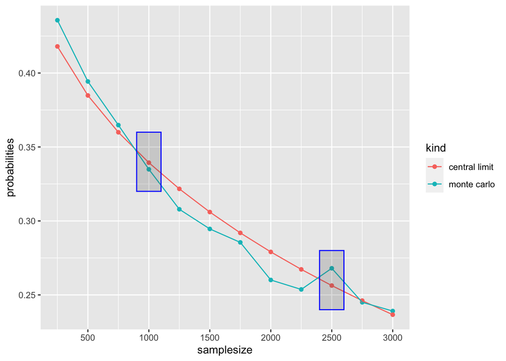

```r
set.seed(1)
library(tidyverse)
nn <- seq(250,3000,250)
B <- 10000
roulette_winnings <- function(n){
  Y <- sample(c(-17,1), n, replace = TRUE, prob=c(1/19, 18/19))
  sum(Y)
}
monte_carlo <- function(n) {
  YR <- replicate(B, roulette_winnings(n))
  mean(YR<0)
}
mc<-sapply(nn, monte_carlo)

central_limit<-function(n) {
  mu <- n * (2)/38
  se <-  sqrt(n) * 18 * sqrt(18)/19
  pnorm(0, mu, se)
}
clt<-sapply(nn, central_limit)

df_mc<-data.frame(samplesize=nn,probabilities=mc,kind="monte carlo")
df_clt<-data.frame(samplesize=nn,probabilities=clt,kind="central limit")
df<-bind_rows(df_mc, df_clt)

ggplot(df,aes(samplesize,probabilities)) +
  geom_point(aes(color=kind)) +
  geom_line(aes(color=kind)) +
  scale_x_continuous(breaks = scales::pretty_breaks(n = 10)) +
  annotate("rect", xmin = 900, xmax = 1100, ymin = 0.32, ymax = 0.36, alpha = .2, color="blue") +
  annotate("rect", xmin = 2400, xmax = 2600, ymin = 0.24, ymax = 0.28, alpha = .2, color="blue")
```

## 14.2 Exercises: The Big Short

### 14.2.1 Qn

> 1. Create a random variable $S$ with the earnings of your bank if you give out 10,000 loans, the default rate is 0.3, and you lose $200,000 in each foreclosure. Hint: use the code we showed in the previous section, but change the parameters.

(Instead of a rate of 0.3 a rate of 0.03 will be used, because it looks like a type in the original question. A default rate of 3% is more reasonable than 30%, which would mean that almost every third customer’s loan defaults.) The assumptions are that a bank will give out 10.000 loans, where each loan amount is $180.000, resulting in $1.800.000.000. From that loans the bank looses $200.000 per foreclosures including all operational costs. In the example in the book the default rate is 2% for 1.000 loans and the resulting loss is about $4 million. By increasing the number of loans by 10-fold to 10.000, the losses consequently also increase in an order of magnitude to $40 million. If the default rate is increased to 3% the losses increase to $63 million.

```r
n <- 10000
loss_per_foreclosure <- -200000
p <- 0.03
set.seed(1)
S <- sample( c(0,1), n, prob=c(1-p, p), replace = TRUE)
sum(S * loss_per_foreclosure)
```

```
## [1] -6.3e+07
```

### 14.2.2 Qn

> 2. Run a Monte Carlo simulation with 10,000 outcomes for $S$. Make a histogram of the results.

```r
n <- 10000
loss_per_foreclosure <- -200000
p <- 0.03
set.seed(1)

B <- 10000
S <- replicate(B, {
    defaults <- sample( c(0,1), n, prob=c(1-p, p), replace = TRUE)
    sum(defaults * loss_per_foreclosure)
})
mean(S)
```

```
## [1] -60026400
```

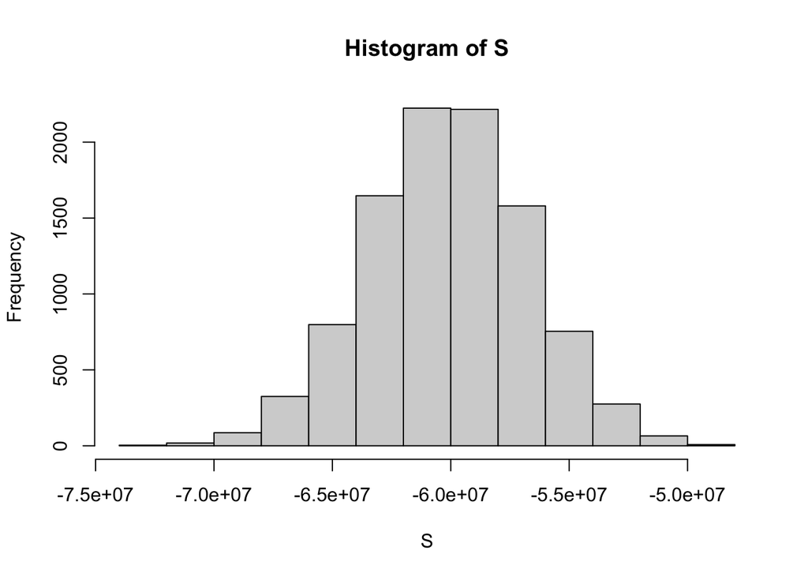

```r
hist(S)
```

### 14.2.3 Qn

> 3. What is the expected value of $S$?

```r
n <- 10000
loss_per_foreclosure <- -200000
p <- 0.03

#CLT: losses only, therefore x=0
n*(p*loss_per_foreclosure+(1-p)*0)
```

```
## [1] -6e+07
```

```r
# -60.000.000
# including an interest rate of 2,3% interest rate
n*(p*loss_per_foreclosure+(1-p)*4082)
```

```
## [1] -20404600
```

```r
# -20.404.600
```

> 4. What is the standard error of $S$?

```r
n <- 10000
loss_per_foreclosure <- -200000
p <- 0.03

sqrt(n)*abs(loss_per_foreclosure)*sqrt(p*(1-p))
```

```
## [1] 3411744
```

```r
#9.165.151
```

It follows that the bank loses 60 million dollars with an error of plus/minus 3 million dollars.

### 14.2.4 Qn

> 5. Suppose we give out loans for $180,000. What should the interest rate be so that our expected value is 0?

```r
loss_per_foreclosure <- -200000
p <- 0.03
loan<-180000
r <- (- loss_per_foreclosure*p/(1-p)) / loan
r
```

```
## [1] 0.03436426
```

```r
x <- r*loan
loss_per_foreclosure*p + x * (1-p)# expected profit per loan
```

```
## [1] 0
```

### 14.2.5 Qn

> 6. (Harder) What should the interest rate be so that the chance of losing money is 1 in 20? In math notation, what should the interest rate be so that $\mbox{Pr}(S<0) = 0.05$ ?

In the “Big Short” chapter 14.11.1 it was shown that
$$\mbox{Pr}\left(S < 0\right) = \mbox{Pr}\left(\frac{S - \mbox{E}[S]}{\mbox{SE}[S]} < \frac{ - \mbox{E}[S]}{\mbox{SE}[S]}\right) = \mbox{Pr}\left(Z < \frac{- \{ lp + x(1-p)\}n}{(x-l) \sqrt{np(1-p)}}\right) = \mbox{Pr}\left(Z < z\right)$$
where $\mbox{E}[S]$ is the expected value and $\mbox{SE}[S]$ the standard error of $S$. The uppercase letter $Z$ is the normalized random variable $S$ with values between 0 and 1. In chapter 13 question 6 it was found that the probability can be computed with the R function $\mbox{pnorm}(z)=p$. Therefore the z-transform can be computed by the inverse `pnorm` function which is `qnorm`: `qnorm(p)`$=z$.
Reminder: The normal distribution was defined as $F(a)=\mbox{Pr}(X<a)=\mbox{pnorm}(a,m,s)=\mbox{mean}(X<a)$ and the standard normal distribution as $F(z)=\mbox{Pr}\left(Z < z\right)=\mbox{pnorm}(z)$. It follows that $F(z)^{-1} = \mbox{qnorm(p)}=z$

```r
loan<-180000
p <- 0.03
n<-10000
loss_per_foreclosure <- -200000
l <- loss_per_foreclosure
z <- qnorm(0.05)
x <- -l*( n*p - z*sqrt(n*p*(1-p)))/ ( n*(1-p) + z*sqrt(n*p*(1-p)))
x/loan # interest rate
```

```
## [1] 0.03768738
```

```r
loss_per_foreclosure*p + x*(1-p) # expected profit per loan
```

```
## [1] 580.2166
```

```r
n*(loss_per_foreclosure*p + x*(1-p))  # total expected profit
```

```
## [1] 5802166
```

The profit per loan is 580 dollars.

### 14.2.6 Qn

> 7. If the bank wants to minimize the probabilities of losing money, which of the following does **not** make interest rates go up?

>    A. A smaller pool of loans.

>    B. A larger probability of default.

>    C. A smaller required probability of losing money.

>    D. The number of Monte Carlo simulations.

Answer D.
The number of Monte Carlo simulations is independent from the interest rate, as can be seen from the following equation, that is derived in the book chapter 14.11.1 “Interest rates explained with chance model”. All other variables n, p and z from answers A, B and C depend on the interest rate.
$$x = - l \frac{ np - z \sqrt{np(1-p)}}{n(1-p) + z \sqrt{np(1-p)}}$$
The interest rate needs to go up in order to compensate the increase probability of possible losses.
The probability of losing money goes up, if the pool of loans decreases (i.e. decreasing n in the calculation: $x\sim 1/n$), because then a default of a single loan results in larger impact to the total earnings (Answer A). Similar a larger probability of defaults results (i.e. increasing p in the calculation: $x\sim p$) in larger losses and has to be compensated by an increase of interest rates (Answer B). Also a smaller required probability of losing money (i.e. decreasing z: $x\sim 1/z$) means higher earnings.

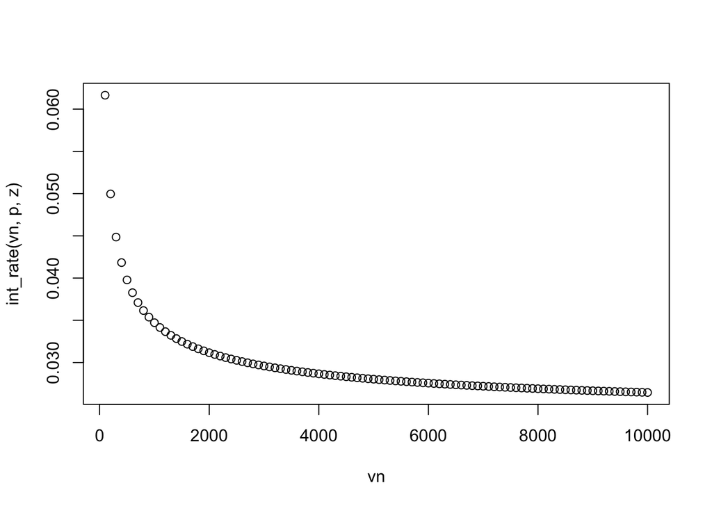

```r
loan<-180000
p <- 0.02
vp<- seq(0.005,0.1,0.005)
n<-1000
vn<-seq(100,10000,100)

loss_per_foreclosure <- -200000
l <- loss_per_foreclosure
z <- qnorm(0.01)
vz<-qnorm(vp)

int_rate<- function(n,p,z) {
  x<- -l*( n*p - z*sqrt(n*p*(1-p)))/ ( n*(1-p) + z*sqrt(n*p*(1-p)))
  x/loan # interest rate
}
# interest rate increases when number of loans decreases
plot(vn, int_rate(vn,p,z))
```

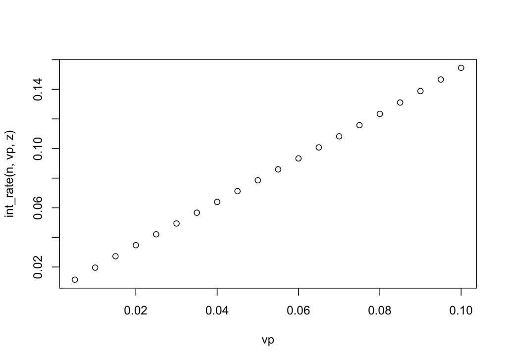

```r
# interest rate increases when default probability increases
plot(vp, int_rate(n,vp,z))
```

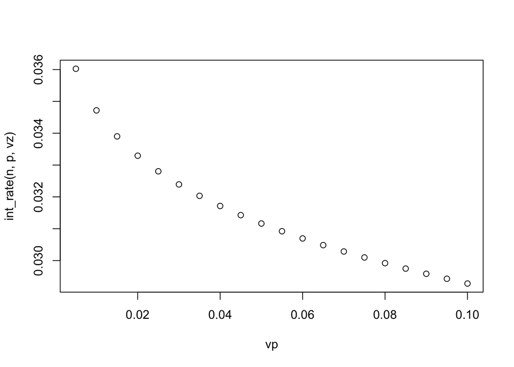

```r
#interest rate increases when probability of loosing money decreases
plot(vp, int_rate(n,p,vz))
```

The described qualitative results are illustrated by the shown plots. Here the reciprocal behavior of $x\sim 1/n$ and $x\sim 1/z$ are shown, but also the proportional behavior of $x\sim p$.